# Airport Analysis

James Abrams & ChatGPT

2023-06-02

# Introduction

This analysis focuses on the LAX departures dataset. The dataset contains information about the number of departures to different airports from Los Angeles International Airport (LAX). We will explore the top destinations and categorize them as domestic or international flights. This report focuses entirely on the Thomas Bradley terminal.

#### **Questions to be answered**

1. Where are the most popular destinations for outbound flights?
2. What proportion of flights are international vs. domestic?
3. Which airlines are the most prominent?
4. What are the most popular times of day for flights to depart?

#### **What are the most popular destinations for outgoing flights from the Thomas Brady terminal at LAX?**

To determine the most popular destinations for outgoing flights from the Thomas Brady terminal at LAX, we have analyzed the dataset and identified the top 10 destinations based on the number of departures.

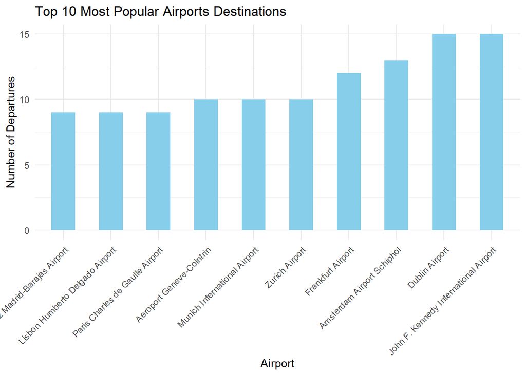

#### **What is the proportion of Domestic flights compared to International flights leaving the terminal?**

To understand the distribution of flights leaving the terminal, we have analyzed the proportion of domestic and international flights.

Proportion of Domestic Vs International Flights

| destination | total | proportion |
| --- | --- | --- |
| Domestic | 38 | 0.08 |
| International | 459 | 0.92 |

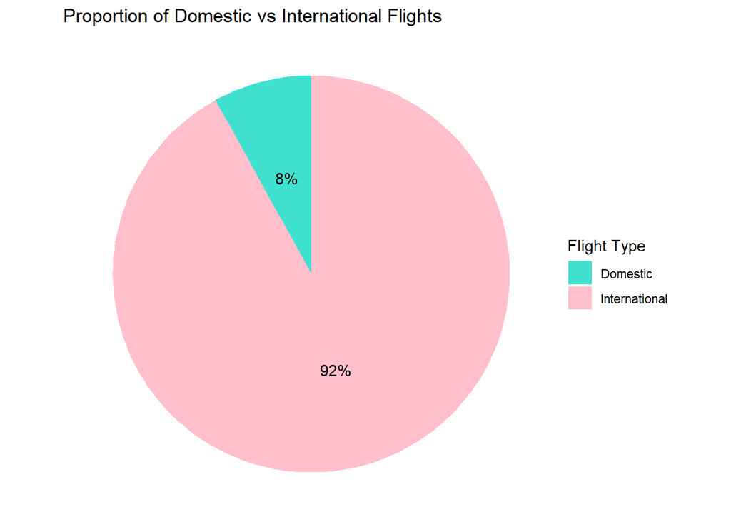

The table above shows the proportion of domestic and international flights leaving the terminal. It provides insights into the balance between domestic and international air traffic.

As we can see, **8%** of the flights leaving the terminal are **domestic**, while **92%** are **international**.

#### **What are the top 10 most popular airlines departing the terminal?**

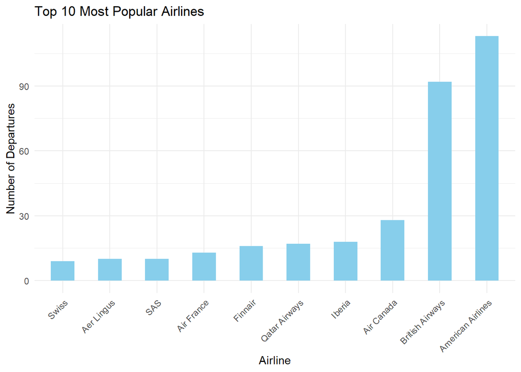

The bar chart above displays the top 10 most popular airlines based on the number of departures. It provides insights into the prominence of different airlines at LAX (Los Angeles International Airport).

As we can see, the most popular airline based on the number of departures is **American Airlines**, with **113** outgoing flights.

#### **What are the busiest times of day?**

To identify the most popular times of day for flights to depart, we have analyzed the dataset and categorized the departure times into hourly time slots.

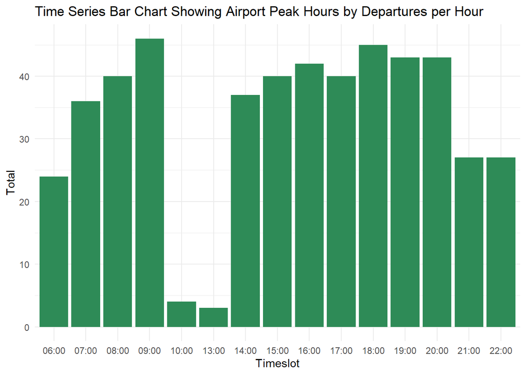

The time series bar chart above illustrates the distribution of departures per hour, highlighting the busiest periods at the airport. Each bar represents a one-hour time slot, and the height of the bar represents the total number of departures during that time slot.

Based on the chart, the busiest time of day for departures from the Thomas Bradley terminal at LAX is **09:00**. During this period, there is a significant surge in departures, indicating a high level of activity at the airport.

Conversely, the quietest time of day for departures is **13:00**. During this period, the number of departures is relatively low, indicating a more peaceful and less crowded environment at the airport.